# Regression and model validation

- First we read in the dataset

```r
students2014 <- read.csv("C:/Users/Kalka/OneDrive/Desktop/Random/School/Open_Data/IODS-project/learning2014.csv")
## This dataset consists of information from 166 people on 7 different parameters including their gender,age, and certain learning questionnaire parameters. The point of the questionnaire was to see how the students course results correlate with their learning approaches and attitude towards a certain statistics course. Deep stra and surf correlate to study skill dimensions
students2014
```

```
##     gender Age attitude     deep  stra     surf Points
## 1        F  53      3.7 3.583333 3.375 2.583333     25
## 2        M  55      3.1 2.916667 2.750 3.166667     12
## 3        F  49      2.5 3.500000 3.625 2.250000     24
## 4        M  53      3.5 3.500000 3.125 2.250000     10
## 5        M  49      3.7 3.666667 3.625 2.833333     22
## 6        F  38      3.8 4.750000 3.625 2.416667     21
## 7        M  50      3.5 3.833333 2.250 1.916667     21
## 8        F  37      2.9 3.250000 4.000 2.833333     31
## 9        M  37      3.8 4.333333 4.250 2.166667     24
## 10       F  42      2.1 4.000000 3.500 3.000000     26
## 11       M  37      3.9 3.583333 3.625 2.666667     31
## 12       F  34      3.8 3.833333 4.750 2.416667     31
## 13       F  34      2.4 4.250000 3.625 2.250000     23
## 14       F  34      3.0 3.333333 3.500 2.750000     25
```

[output cut: 152 more lines]

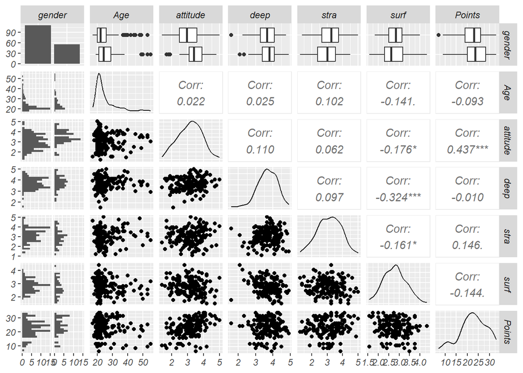

```r
# graphical overview of the data can be shown by using ggpairs
library(GGally)
library(ggplot2)
# create an plot matrix with ggpairs()
ggpairs(students2014, lower = list(combo = wrap("facethist", bins = 20)))
```

```r
# create a regression model with multiple explanatory variables
my_model2 <- lm(Points ~ attitude + stra+surf+deep+Age+gender, data = students2014)

# print out a summary of the model
summary(my_model2)
```

```
##
## Call:
## lm(formula = Points ~ attitude + stra + surf + deep + Age + gender,
##     data = students2014)
##
## Residuals:
##      Min       1Q   Median       3Q      Max
## -17.4506  -3.2479   0.3879   3.5243  11.4820
##
## Coefficients:
##             Estimate Std. Error t value Pr(>|t|)
## (Intercept) 18.30246    5.25723   3.481 0.000644 ***
## attitude     3.44300    0.59776   5.760 4.24e-08 ***
## stra         0.95871    0.55150   1.738 0.084083 .
## surf        -1.10891    0.84467  -1.313 0.191132
## deep        -1.04279    0.78438  -1.329 0.185606
## Age         -0.09607    0.05396  -1.780 0.076929 .
## genderM     -0.05858    0.92985  -0.063 0.949845
## ---
## Signif. codes:  0 '***' 0.001 '**' 0.01 '*' 0.05 '.' 0.1 ' ' 1
##
## Residual standard error: 5.265 on 159 degrees of freedom
## Multiple R-squared:  0.2312, Adjusted R-squared:  0.2021
## F-statistic: 7.967 on 6 and 159 DF,  p-value: 1.599e-07
```

- in this overview you can see the different correlations between points that the student got and the answers they gave. From this we can say that a positive attitude towards statistics correlated positively with points gained from the course. The other factors did not correlate with statistical significance towards the points
- Below is a summary of how this data shows the correlation of attitude age and strategical methods towards a course and the results on a linear regression model. The only one that correlates stronly is once again the attitude, However stra and age also seem to have some correlation but not statistically significant.

```r
library(ggplot2)

# fit a linear model
my_model <- lm(Points ~ attitude+Age+stra, data = students2014)

# print out a summary of the model
summary(my_model)
```

```
##
## Call:
## lm(formula = Points ~ attitude + Age + stra, data = students2014)
##
## Residuals:
##      Min       1Q   Median       3Q      Max
## -18.1149  -3.2003   0.3303   3.4129  10.7599
##
## Coefficients:
##             Estimate Std. Error t value Pr(>|t|)
## (Intercept) 10.89543    2.64834   4.114 6.17e-05 ***
## attitude     3.48077    0.56220   6.191 4.72e-09 ***
## Age         -0.08822    0.05302  -1.664   0.0981 .
## stra         1.00371    0.53434   1.878   0.0621 .
## ---
## Signif. codes:  0 '***' 0.001 '**' 0.01 '*' 0.05 '.' 0.1 ' ' 1
##
## Residual standard error: 5.26 on 162 degrees of freedom
## Multiple R-squared:  0.2182, Adjusted R-squared:  0.2037
## F-statistic: 15.07 on 3 and 162 DF,  p-value: 1.07e-08
```

-Here we run the fitting again removing the variables that had no statistical significances shown by the *** marking and only run it by explaining points with attitude towards the course and we also plot the two variables that show correlation

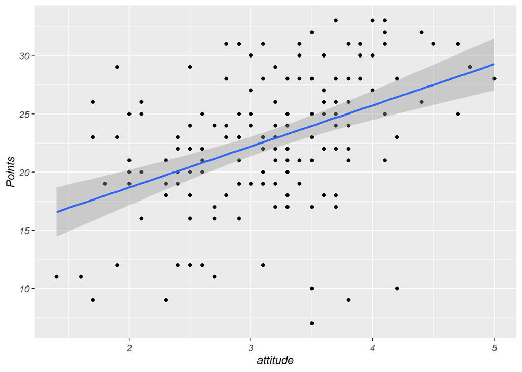

```r
qplot(attitude, Points, data = students2014) + geom_smooth(method = "lm")
```

```r
# fit a linear model
my_model <- lm(Points ~ attitude, data = students2014)

# print out a summary of the model
summary(my_model)
```

```
##
## Call:
## lm(formula = Points ~ attitude, data = students2014)
##
## Residuals:
##      Min       1Q   Median       3Q      Max
## -16.9763  -3.2119   0.4339   4.1534  10.6645
##
## Coefficients:
##             Estimate Std. Error t value Pr(>|t|)
## (Intercept)  11.6372     1.8303   6.358 1.95e-09 ***
## attitude      3.5255     0.5674   6.214 4.12e-09 ***
## ---
## Signif. codes:  0 '***' 0.001 '**' 0.01 '*' 0.05 '.' 0.1 ' ' 1
##
## Residual standard error: 5.32 on 164 degrees of freedom
## Multiple R-squared:  0.1906, Adjusted R-squared:  0.1856
## F-statistic: 38.61 on 1 and 164 DF,  p-value: 4.119e-09
```

- As you see in the summary of a linear model for this data for every scaled point of attitude our expected points increase by 3.52

– note however that the R squared value is only 0.19 which means that our model only accounts for 19% of the variability in the data and thus might not be an accurate method to model this data –> in other words points are only 19% explained by course attitude

- Lastly we produce some diagnostic plots as in ex2

```r
# create a regression model with multiple explanatory variables
my_model2 <- lm(Points ~ attitude, data = students2014)

# draw diagnostic plots using the plot() function. Choose the plots 1, 2 and 5
my_model2
```

```
##
## Call:
## lm(formula = Points ~ attitude, data = students2014)
##
## Coefficients:
## (Intercept)     attitude
##      11.637        3.525
```

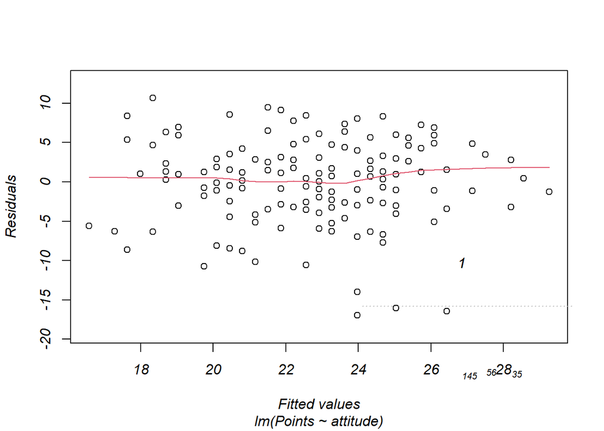

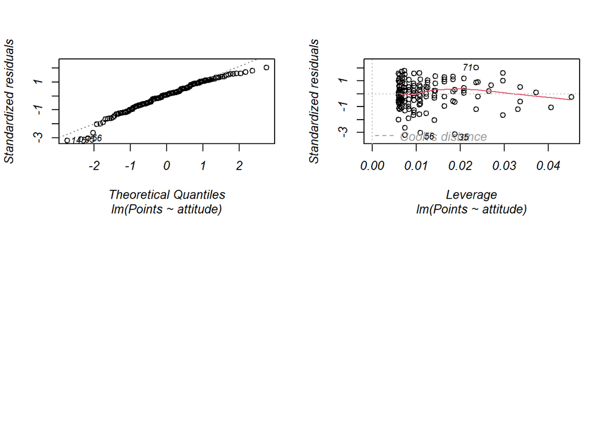

```r
plot(my_model2,which = c(1,2,5),par(mfrow=c(2,2)))
```

- Based on the course book fig 3.4a the Residuals against Fitted values plot shows that our fitted model should be of appropriate quality as there is no clear curvature in our values which would indicate that the model would need transformation.
- for the standardized residuals we see some potential outliers on the left side which may be the reason why our R-squared is so low. Perhaps there are people who get low scores despite having a good attitude score which lower the predictability ?

```r
date()
```

```
## [1] "Mon Dec  4 20:52:28 2023"
```

Here we go again…